# Hit Or Not? - Progetto [Relazione]

*Jeremy Sapienza x81000498*

Il progetto è ispirato ad un'idea rivoluzionaria di una casa discografica chiamata **Snafu**. Essa sostiene di essere la prima **“etichetta discografica basata sull’AI”**.

In cosa consiste il loro lavoro? Ogni settimana mettono all’opera **l’algoritmo proprietario** e passano in rassegna ben **150mila canzoni pubblicate su piattaforme come Spotify, YouTube, SoundCloud e TikTok**. Nell’analisi vengono considerati anche **i post sui blog, i tweet e le aggiunte alle playlist realizzate dagli utenti, il sentiment e l’engagement**. Con tutta questa mole di materiale, Snafu ritiene che il suo software sia in grado di **identificare con largo anticipo, e spesso in modo esclusivo, artisti sconosciuti o trascurati poco dopo che hanno rilasciato i loro primi pezzi**. Tagliando così in modo clamoroso i tempi di scouting, che risentono ovviamente di molti fattori diversi, su tutti la sensibilità di chi ha il potere di decidere su cosa scommettere.

[figure not shown]

Il pensiero di Snafu verte su questa affermazione: **L’industria musicale è bloccata da un modo molto vecchio di lavorare, scoprendo artisti col passaparola**. In questo modo chiunque può sbocciare ed affermarsi nella scena musicale.

Il progetto utilizza per l'analisi dei dati solamente l'API di Spotify per scovare artisti promettenti che potrebbero essere le prossime star nella scena musicale.

[figure not shown]

*(Il team di Snafu)*

## Come Iniziare

Iniziamo adesso ad elaborare i nostri metadati JSON per poter effettuare delle analisi accurate riguardo determinate caratteristiche come: posizione in classifica, playlist ecc..

In questo tutorial mostriamo come analizzare i dati che ci vengono forniti dalle nostre richieste. Il linguaggio che noi utilizzeremo è **Python3**.

*Otteniamo il token per effettuare le nostre richiestre*

```python
import spotipy
import spotipy.util as util
from spotipy.oauth2 import SpotifyClientCredentials
from json.decoder import JSONDecodeError

username = '1168261438'
scope = ''
token = util.prompt_for_user_token(username,
                                   scope,
                                   client_id='insert-your-ID-client',
                                   client_secret='insert-your-secret-client',
                                   redirect_uri='https://google.com')

if token:
    spotify = spotipy.Spotify(auth = token)
else:
    print("Can't get token for", username)
```

*Dopo aver effettuato la connessione all'API per ottenere il token ed effettuare le numerose richieste di dati, creiamo il dataset per la nostra analisi ed utilizziamo un dataset creato in precedenza in cui sono state salvate caratteristiche come: Artist, Song, Total Stream, MediumPositionsINTERN, MediumPositionsALL, PresenceIN, Markets e Genre* (queste informazioni si riferiscono alle classifiche presenti nella data del 4 Marzo 2020).

Il nuovo dataset che interessa la nostra analisi presenta ulteriori features basate sulle caratteristiche audio base delle tracce presenti nel precedente dataset.

```python
with open('dataset_for_proj.csv','w',newline='\n') as new_row:
    thewriter = csv.writer(new_row)

    thewriter.writerow(['Artist','Song','Total Stream','MediumPostionsINTERN'
                        ,'MediumPositionsALL','PresenceIN','Markets','Acousticness'
                        ,'Danceability','Energy','Instrumentalness','Liveness','Loudness'
                        ,'Speechiness','Valence','Key','Mode','Duration_ms','Tempo','Genre'])

    with open('realdataset.csv', 'r', newline='\n') as row:
        thereader = csv.reader(row)
        t = list(thereader)

        #pure_f1 is a list that contains url's song
        for i in range(0,1076):
            list_audio_features = spotify.audio_features(pure_f1[i])
            xx = list_audio_features
            for x in xx:
                thewriter.writerow([t[i][0],t[i][1],t[i][2],t[i][3]
                                ,t[i][4],t[i][5],t[i][6],x['acousticness']
                                ,x['danceability'],x['energy']
                                ,x['instrumentalness'],x['liveness']
                                ,x['loudness'],x['speechiness']
                                ,x['valence'],x['key']
                                ,x['mode'],x['duration_ms']
                                ,x['tempo'],t[i][7]])
    print("dataset created")
```

```
dataset created
```

## Cosa sono le audio features di una canzone?

le Audio Features fornite dall'API sono dodici e sono le caratteristiche base che presenta una determinata canzone. Queste informazioni sono:

- **Acousticness**: è una misura che indica la distribuzione probabilistica(distr. uniforme) della purezza acustica della canzone rispetto alle canzoni elettroniche, il valore è posto tra 0.0 e 1.0 (0.0 significa che la canzone non è acustica, 1.0 viceversa).
- **Danceability**: è una misura che descrive la "ballabilità" della canzone. Questa caratteristica è una combinazione musicale di elementi musicali quali tempo, ritmo, forza del beat ecc. Se il valore è prossimo a 0.0 significa che non è ballabile, 1.0 il contrario.
- **Energy**: è una misura che indica l’energia in una canzone, appunto se possiede dei suoni forti e intensi. 0.0 significa che la canzone non è energica, 1.0 il contrario
- **Instrumentalness**: è una misura che indica se in una canzone risulta essere presente traccia di qualche audio vocale, 1.0 se è puramente una traccia strumentale, 0.0 vuol dire che non è strumentale, ma contiene anche audio vocali.
- **Liveness**: si rileva se una traccia è stata registrata in live o meno. Se il valore è 1.0 corrisponde al fatto che una traccia è stata registrata in live, 0.0 il contrario.
- **Loudness**: la misura è in decibels (dB). I valori di loudness sono considerate come media dell’intera traccia e sono utili per confrontare il volume relativo delle tracce. La loudness è la qualità di una canzone di possedere primariamente una correlazione psicologica della lunghezza fisica (ampiezza). I valori tipicamente sono compresi tra -60 e 0 db.
- **Speechness**: è una misura che indica il testo parlato nella canzone (ovvero canzoni senza cantato ma solo base, ad esempio gli Interlude presenti negli album). Un valore prossimo a 0.0 significa che non esiste il parlato interno alla canzone, un valore pari a 1.0 indica la presenza di parlato. Se il valore è 0.66 significa che possiede sia il parlato che la base.
- **Valence**: indica se una canzone ha un mood più “felice” o “triste”. É un valore di solito molto soggettivo, 1.0 indica una canzone felice, 0.0 l’opposto.
- **Key**: è la chiave con cui è composta la canzone va da 0 a 11 e corrisponde a 0 = C, 1=C# ecc. Se la chiave non è stata rilevata, si pone il valore di -1.
- **Mode**: indica la modalità (minore[0] o maggiore[1], [-1] senza risultato) di una traccia, il tipo di scala dalla melodia ricavata.
- **Tempo**: indica i BPM di una canzone, si deriva dalla media delle durate dei beats nella canzone.
- **Duration_ms**: indica la durata della canzone espressa in millisecondi.

Mostriamo adesso le prime 5 tuple del dataset e le caratteristiche totali di esso.

```python
import pandas as pd
dataset = pd.read_csv('./Scrivania/ProjectWebAPISpotify/dataset_for_proj.csv')

dataset.head()
```

|  | Artist | Song | Total Stream | MediumPositionsINTERN | MediumPositionsALL | PresenceIN | Markets | Acousticness | Danceability | Energy | Instrumentalness | Liveness | Loudness | Speechiness | Valence | Key | Mode | Duration_ms | Tempo | Genre |
| --- | --- | --- | --- | --- | --- | --- | --- | --- | --- | --- | --- | --- | --- | --- | --- | --- | --- | --- | --- | --- |
| 0 | 1.Cuz | FÖRSENT | 51862 | 50.0 | 0.81 | 1 | 79 | 0.180 | 0.937 | 0.707 | 0.000376 | 0.1860 | -5.153 | 0.1460 | 0.766 | 10 | 0 | 182400 | 100.031 | swedish gangsta rap |
| 1 | 24kGoldn | CITY OF ANGELS | 330904 | 38.2 | 0.62 | 10 | 79 | 0.042 | 0.686 | 0.541 | 0.000000 | 0.0675 | -4.993 | 0.0493 | 0.724 | 0 | 0 | 112493 | 120.084 | cali rap |
| 2 | 47ter | Côte Ouest | 138991 | 24.0 | 0.39 | 1 | 3 | 0.534 | 0.772 | 0.596 | 0.000000 | 0.1720 | -7.962 | 0.1020 | 0.603 | 8 | 1 | 232653 | 152.057 | french hip hop |
| 3 | 4Keus | MD (feat. Niska) | 203187 | 9.0 | 0.15 | 1 | 6 | 0.499 | 0.410 | 0.729 | 0.000000 | 0.1240 | -5.253 | 0.4000 | 0.593 | 4 | 0 | 210827 | 75.301 | french hip hop |
| 4 | 5MIINUST | Aluspükse | 2254 | 15.0 | 0.24 | 1 | 79 | 0.388 | 0.725 | 0.771 | 0.000001 | 0.3620 | -5.551 | 0.2210 | 0.544 | 9 | 0 | 210000 | 119.998 | estonian hip hop |

```python
dataset.describe()
```

|  | Total Stream | MediumPositionsINTERN | MediumPositionsALL | PresenceIN | Markets | Acousticness | Danceability | Energy | Instrumentalness | Liveness | Loudness | Speechiness | Valence | Key | Mode | Duration_ms | Tempo |
| --- | --- | --- | --- | --- | --- | --- | --- | --- | --- | --- | --- | --- | --- | --- | --- | --- | --- |
| count | 1.076000e+03 | 1076.000000 | 1076.000000 | 1076.000000 | 1076.000000 | 1076.000000 | 1076.000000 | 1076.000000 | 1076.000000 | 1076.000000 | 1076.000000 | 1076.000000 | 1076.000000 | 1076.000000 | 1076.000000 | 1076.000000 | 1076.000000 |
| mean | 2.135190e+05 | 27.651385 | 0.445994 | 2.880112 | 73.666357 | 0.298935 | 0.680242 | 0.631374 | 0.008468 | 0.176084 | -6.704088 | 0.120882 | 0.517872 | 5.579926 | 0.578067 | 206002.799257 | 122.154926 |
| std | 5.310625e+05 | 13.830586 | 0.223222 | 6.074693 | 18.629040 | 0.254954 | 0.144348 | 0.167972 | 0.061393 | 0.151437 | 2.590963 | 0.109320 | 0.214446 | 3.602858 | 0.494098 | 45966.929994 | 29.147467 |
| min | 1.057000e+03 | 1.000000 | 0.020000 | 1.000000 | 1.000000 | 0.000700 | 0.221000 | 0.101000 | 0.000000 | 0.019700 | -18.717000 | 0.024100 | 0.051700 | 0.000000 | 0.000000 | 84987.000000 | 51.533000 |
| 25% | 1.467600e+04 | 16.515000 | 0.270000 | 1.000000 | 78.000000 | 0.084800 | 0.583000 | 0.530750 | 0.000000 | 0.098675 | -7.962500 | 0.042200 | 0.351000 | 2.000000 | 0.000000 | 174752.000000 | 97.990500 |
| 50% | 6.233000e+04 | 29.000000 | 0.470000 | 1.000000 | 79.000000 | 0.223500 | 0.697000 | 0.648000 | 0.000000 | 0.122000 | -6.351000 | 0.070950 | 0.508000 | 6.000000 | 1.000000 | 198026.500000 | 119.963500 |
| 75% | 1.604425e+05 | 40.000000 | 0.650000 | 1.000000 | 79.000000 | 0.465750 | 0.789000 | 0.750000 | 0.000011 | 0.192250 | -4.974250 | 0.171000 | 0.688000 | 9.000000 | 1.000000 | 227376.500000 | 142.039250 |
| max | 5.640387e+06 | 50.000000 | 0.810000 | 60.000000 | 79.000000 | 0.978000 | 0.973000 | 0.979000 | 0.897000 | 0.982000 | -0.824000 | 0.560000 | 0.976000 | 11.000000 | 1.000000 | 464200.000000 | 204.135000 |

Il nostro obiettivo è quello di analizzare una canzone sconosciuta e di inserirla in un pool di canzoni che posseggono caratteristiche audio simili con la nuova traccia. Considerando quindi questo pool di canzoni, ipotizziamo i valori di: Total Stream, MediumPositionsINTERN, MediumPositionsALL, PresenceIN.

In questo modo, ipoteticamente, se siamo in presenza di un Hit o No, occorre andare a normalizzare il range di valori delle features appena citate poichè hanno dei range non ben distribuiti.

```python
#Z-Scaling used for normalized the ranges, First Part
normalized_dataset = dataset.copy()
normalized_dataset[['Total Stream', 'MediumPositionsINTERN', 'MediumPositionsALL', 'PresenceIN']] = (dataset[['Total Stream', 'MediumPositionsINTERN', 'MediumPositionsALL', 'PresenceIN']] - dataset[['Total Stream', 'MediumPositionsINTERN', 'MediumPositionsALL', 'PresenceIN']].mean())/dataset[['Total Stream', 'MediumPositionsINTERN', 'MediumPositionsALL', 'PresenceIN']].std()
normalized_dataset.head()
```

|  | Artist | Song | Total Stream | MediumPositionsINTERN | MediumPositionsALL | PresenceIN | Markets | Acousticness | Danceability | Energy | Instrumentalness | Liveness | Loudness | Speechiness | Valence | Key | Mode | Duration_ms | Tempo | Genre |
| --- | --- | --- | --- | --- | --- | --- | --- | --- | --- | --- | --- | --- | --- | --- | --- | --- | --- | --- | --- | --- |
| 0 | 1.Cuz | FÖRSENT | -0.304403 | 1.615883 | 1.630691 | -0.309499 | 79 | 0.180 | 0.937 | 0.707 | 0.000376 | 0.1860 | -5.153 | 0.1460 | 0.766 | 10 | 0 | 182400 | 100.031 | swedish gangsta rap |
| 1 | 24kGoldn | CITY OF ANGELS | 0.221038 | 0.762702 | 0.779519 | 1.172057 | 79 | 0.042 | 0.686 | 0.541 | 0.000000 | 0.0675 | -4.993 | 0.0493 | 0.724 | 0 | 0 | 112493 | 120.084 | cali rap |
| 2 | 47ter | Côte Ouest | -0.140338 | -0.264008 | -0.250847 | -0.309499 | 3 | 0.534 | 0.772 | 0.596 | 0.000000 | 0.1720 | -7.962 | 0.1020 | 0.603 | 8 | 1 | 232653 | 152.057 | french hip hop |
| 3 | 4Keus | MD (feat. Niska) | -0.019455 | -1.348561 | -1.326011 | -0.309499 | 6 | 0.499 | 0.410 | 0.729 | 0.000000 | 0.1240 | -5.253 | 0.4000 | 0.593 | 4 | 0 | 210827 | 75.301 | french hip hop |
| 4 | 5MIINUST | Aluspükse | -0.397816 | -0.914740 | -0.922824 | -0.309499 | 79 | 0.388 | 0.725 | 0.771 | 0.000001 | 0.3620 | -5.551 | 0.2210 | 0.544 | 9 | 0 | 210000 | 119.998 | estonian hip hop |

```python
normalized_dataset.describe()
```

|  | Total Stream | MediumPositionsINTERN | MediumPositionsALL | PresenceIN | Markets | Acousticness | Danceability | Energy | Instrumentalness | Liveness | Loudness | Speechiness | Valence | Key | Mode | Duration_ms | Tempo |
| --- | --- | --- | --- | --- | --- | --- | --- | --- | --- | --- | --- | --- | --- | --- | --- | --- | --- |
| count | 1.076000e+03 | 1.076000e+03 | 1.076000e+03 | 1.076000e+03 | 1076.000000 | 1076.000000 | 1076.000000 | 1076.000000 | 1076.000000 | 1076.000000 | 1076.000000 | 1076.000000 | 1076.000000 | 1076.000000 | 1076.000000 | 1076.000000 | 1076.000000 |
| mean | 2.641423e-17 | -4.886632e-16 | -5.761604e-16 | 1.981067e-17 | 73.666357 | 0.298935 | 0.680242 | 0.631374 | 0.008468 | 0.176084 | -6.704088 | 0.120882 | 0.517872 | 5.579926 | 0.578067 | 206002.799257 | 122.154926 |
| std | 1.000000e+00 | 1.000000e+00 | 1.000000e+00 | 1.000000e+00 | 18.629040 | 0.254954 | 0.144348 | 0.167972 | 0.061393 | 0.151437 | 2.590963 | 0.109320 | 0.214446 | 3.602858 | 0.494098 | 45966.929994 | 29.147467 |
| min | -4.000697e-01 | -1.926989e+00 | -1.908391e+00 | -3.094990e-01 | 1.000000 | 0.000700 | 0.221000 | 0.101000 | 0.000000 | 0.019700 | -18.717000 | 0.024100 | 0.051700 | 0.000000 | 0.000000 | 84987.000000 | 51.533000 |
| 25% | -3.744249e-01 | -8.051998e-01 | -7.884287e-01 | -3.094990e-01 | 78.000000 | 0.084800 | 0.583000 | 0.530750 | 0.000000 | 0.098675 | -7.962500 | 0.042200 | 0.351000 | 2.000000 | 0.000000 | 174752.000000 | 97.990500 |
| 50% | -2.846916e-01 | 9.750962e-02 | 1.075414e-01 | -3.094990e-01 | 79.000000 | 0.223500 | 0.697000 | 0.648000 | 0.000000 | 0.122000 | -6.351000 | 0.070950 | 0.508000 | 6.000000 | 1.000000 | 198026.500000 | 119.963500 |
| 75% | -9.994401e-02 | 8.928483e-01 | 9.139145e-01 | -3.094990e-01 | 79.000000 | 0.465750 | 0.789000 | 0.750000 | 0.000011 | 0.192250 | -4.974250 | 0.171000 | 0.688000 | 9.000000 | 1.000000 | 227376.500000 | 142.039250 |
| max | 1.021889e+01 | 1.615883e+00 | 1.630691e+00 | 9.402926e+00 | 79.000000 | 0.978000 | 0.973000 | 0.979000 | 0.897000 | 0.982000 | -0.824000 | 0.560000 | 0.976000 | 11.000000 | 1.000000 | 464200.000000 | 204.135000 |

Cerchiamo una canzone che non risulta essere in classifica, se fosse presente è categorizzata come HIT.

```python
#Search a song on spotify, so get information about this song
search = input("This is a search bar put more information: ")

search_song = input("Insert Song Name: ")
search_artist = input("Insert Artist Name: ")

check_artist = (search_artist == normalized_dataset.Artist).any()
check_song = (search_song == normalized_dataset.Song).any()
```

```
This is a search bar put more information: Notte Xavier Foster
Insert Song Name: Notte
Insert Artist Name: Xavier Foster
```

Se la canzone risulta non essere presente nel nostro dataset, effettuiamo la ricerca andando ad estrarre alcune features importanti.

```python
if check_song & check_artist:
    print("IS A HIT")
else:
    search_uri_song = "none"
    search_uri_artist = "none"
    search_numbermarkets = 0

    aa = spotify.search(search)
    items = aa['tracks']['items']
    flg = 0
    for a in items:
        if a['artists'][0]['name'] == search_artist:
            if a['name'] == search_song:
                print(" \nSong found, i'm catching the song and artist uri")
                search_uri_song = a['uri']
                search_uri_artist = a['artists'][0]['uri']
                search_numbermarkets = len(a['available_markets'])
                flg = 1

    if flg == 0:
        print("Not found")
        exit()
```

```
Song found, i'm catching the song and artist uri
```

Trovata la canzone riempiamo le celle della nuova tupla, per quanto sia possibile come descritto in precedenza, al fine di inserirla nel nostro dataset ed effettuare il raggruppamento delle canzoni che posseggono un suono simile.

```python
#get audio features and genre
temp = {}
if search_uri_artist and search_uri_song != "none":

    aa = spotify.artist(search_uri_artist)
    if aa['genres']:
        found_genre = aa['genres'][0]
    else:
        found_genre = "no genres"

    bb = spotify.audio_features(search_uri_song)
    for x in bb:
        temp = {
            'Acousticness' : x['acousticness'],
            'Danceability' : x['danceability'],
            'Energy' : x['energy'],
            'Instrumentalness' : x['instrumentalness'],
            'Liveness' : x['liveness'],
            'Loudness' : x['loudness'],
            'Speechiness' : x['speechiness'],
            'Valence' : x['valence'],
            'Key' : x['key'],
            'Mode' : x['mode'],
            'Duration_ms' : x['duration_ms'],
            'Tempo' : x['tempo']
        }

row_to_add = pd.DataFrame( {
                    'Artist': [search_artist],
                    'Song': [search_song],
                    'Total Stream': 1,
                    'MediumPositionsINTERN': 1,
                    'MediumPositionsALL': 1,
                    'PresenceIN': 1,
                    'Markets':[search_numbermarkets],
                    'Acousticness':[temp['Acousticness']],
                    'Danceability': [temp['Danceability']],
                    'Energy': [temp['Energy']],
                    'Instrumentalness': [temp['Instrumentalness']],
                    'Liveness': [temp['Liveness']],
                    'Loudness': [temp['Loudness']],
                    'Speechiness': [temp['Speechiness']],
                    'Valence': [temp['Valence']],
                    'Key': [temp['Key']],
                    'Mode': [temp['Mode']],
                    'Duration_ms': [temp['Duration_ms']],
                    'Tempo': [temp['Tempo']],
                    'Genre': [found_genre]
                    } )

#Z-Scaling used for normalized the ranges, Second Part
normalized_dataset = normalized_dataset.append(row_to_add, ignore_index=True)
normalized_dataset[['Markets']] = (normalized_dataset[['Markets']] - normalized_dataset[['Markets']].mean())/normalized_dataset[['Markets']].std()
```

Visualizziamo le ultime 5 tuple inserite, i valori momentanei di Notte sono impostati con valore pari a uno. Tali valori dopo il clustering del dataset verranno reimpostati inserendo i valori ipotetici.

```python
normalized_dataset.tail()
```

|  | Artist | Song | Total Stream | MediumPositionsINTERN | MediumPositionsALL | PresenceIN | Markets | Acousticness | Danceability | Energy | Instrumentalness | Liveness | Loudness | Speechiness | Valence | Key | Mode | Duration_ms | Tempo | Genre |
| --- | --- | --- | --- | --- | --- | --- | --- | --- | --- | --- | --- | --- | --- | --- | --- | --- | --- | --- | --- | --- |
| 1072 | 音阙诗听 | 芒种 | -0.371478 | 1.398973 | 1.406698 | -0.309499 | 0.286164 | 0.723 | 0.781 | 0.656 | 0.068900 | 0.1140 | -5.862 | 0.0310 | 0.548 | 8 | 1 | 216000 | 99.981 | mainland chinese pop |
| 1073 | 高爾宣 OSN | Why You Gonna Lie | -0.360110 | -0.625526 | -0.609235 | -0.309499 | 0.286164 | 0.763 | 0.768 | 0.760 | 0.000000 | 0.1410 | -3.729 | 0.1050 | 0.736 | 7 | 1 | 174000 | 90.000 | taiwan hip hop |
| 1074 | 高爾宣 OSN | Without You | -0.337119 | -1.854685 | -1.863593 | -0.309499 | 0.286164 | 0.571 | 0.669 | 0.698 | 0.000000 | 0.1020 | -4.613 | 0.0910 | 0.286 | 11 | 1 | 175500 | 80.003 | taiwan hip hop |
| 1075 | 高爾宣 OSN | 最後一次 | -0.365605 | -0.047097 | -0.026854 | -0.309499 | 0.286164 | 0.515 | 0.708 | 0.639 | 0.000000 | 0.1020 | -4.173 | 0.0648 | 0.293 | 5 | 1 | 166000 | 89.994 | taiwan hip hop |
| 1076 | Xavier Foster | Notte | 1.000000 | 1.000000 | 1.000000 | 1.000000 | 0.286164 | 0.261 | 0.653 | 0.490 | 0.000008 | 0.0922 | -8.529 | 0.0324 | 0.604 | 11 | 1 | 186000 | 79.998 | no genres |

Applichiamo il nostro algoritmo di **unsupervised learning**, il **KMeans**, al fine di poter andare a raggruppare le canzoni su k cluster.

Utilizziamo una funzione importante per poter abbassare l'elevata dimensionalità del nostro dataset da 8 features a 2 features.

Il **PCA** (Principal component analysis), anche nota come trasformata di Karhunen-Loève, trasformata di Hotelling o decomposizione ortogonale propria, **è una tecnica per la semplificazione dei dati utilizzata nell'ambito della statistica multivariata**.

Lo scopo della tecnica è quello di ridurre il numero più o meno elevato di variabili che descrivono un insieme di dati a un numero minore di variabili latenti, limitando il più possibile la perdita di informazioni.

**Come avviene questa trasformazione?** Tramite una **trasformazione lineare** delle variabili che **proietta** quelle originarie in un **nuovo sistema cartesiano** in cui la nuova variabile con la maggiore varianza viene proiettata sul primo asse, la variabile nuova, seconda per dimensione della varianza, sul secondo asse e così via.

La riduzione della complessità avviene limitandosi ad analizzare le principali, per varianza, tra le nuove variabili.

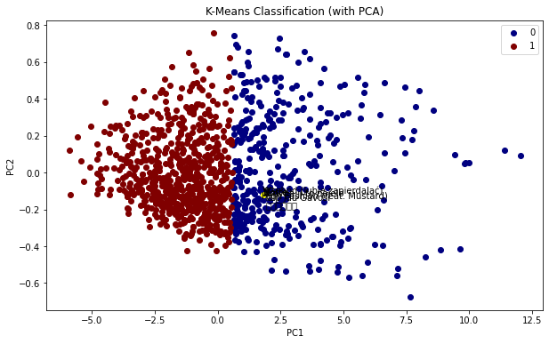

```python
#libraries for machine learning
from sklearn.cluster import KMeans
from sklearn.metrics import silhouette_samples
from sklearn.decomposition import PCA

#To Plot the Points
from matplotlib import pyplot as plt

#remove warnings, it relate with fonts istallation
import warnings
warnings.filterwarnings("ignore", category=RuntimeWarning)

#KMeans Algorithm
X = normalized_dataset[['Acousticness', 'Danceability', 'Energy', 'Instrumentalness', 'Liveness', 'Loudness', 'Speechiness', 'Valence']]

clustering = KMeans(n_clusters=2)
labels = clustering.fit_predict(X)

pca = PCA(n_components=2)
data_reduced = pca.fit_transform(X)
data_reduced = pd.DataFrame(data_reduced)

ax = data_reduced.plot(kind='scatter', x=0, y=1)
ax.set_xlabel('PC1')
ax.set_ylabel('PC2')
ax.set_title('K-Means Classification (with PCA)')

unique = list(set(labels))
colors = [plt.cm.jet(float(i)/max(unique)) for i in unique]
for i, u in enumerate(unique):
    xi = [data_reduced[0][j] for j  in range(len(data_reduced)) if labels[j] == u]
    yi = [data_reduced[1][j] for j  in range(len(data_reduced)) if labels[j] == u]
    plt.scatter(xi, yi, c=[colors[i]], label=str(u))

normalized_dataset['Labels'] = labels
for i, txt in enumerate(normalized_dataset.Song):
    if (normalized_dataset.loc[i,'Labels'] == normalized_dataset.loc[len(normalized_dataset)-1,'Labels']):

        if  ( (data_reduced[0].iat[i] < ( data_reduced[0].iat[len(normalized_dataset)-1] + 0.1 ) ) and (data_reduced[0].iat[i] > ( data_reduced[0].iat[len(normalized_dataset)-1] - 0.1 )) ):

            if  ( (data_reduced[1].iat[i] < ( data_reduced[1].iat[len(normalized_dataset)-1] + 0.1 ) ) and (data_reduced[1].iat[i] > ( data_reduced[1].iat[len(normalized_dataset)-1] - 0.1 )) ):
                ax.annotate(txt, (data_reduced[0].iat[i],data_reduced[1].iat[i]))

    if i == len(normalized_dataset) - 1:
        ax.annotate(txt, (data_reduced[0].iat[i],data_reduced[1].iat[i]))
        plt.scatter(data_reduced[0].iat[i],data_reduced[1].iat[i], c="yellow")  #only to display in the plot the new song

plt.rcParams['figure.figsize'] = 10, 10
plt.legend()

plt.show()
```

Viene ingrandita l'immagine in cui è presente la canzone plottando le canzoni che posseggono audio simili.

[figure not shown]

Sentiamo come l'audio risulta essere simile, per non rallentare la lettura del file importiamo l'audio delle due canzoni più vicine alla canzone da noi scelta per l'analisi come mostrato nel grafico precedente.

```python
from IPython.display import YouTubeVideo

id_notte = 'vcKVLJaTkwQ'
YouTubeVideo(id=id_notte, width=550,height=400)
```

[video not shown]

```python
id_zrovna = 'RPO6RstNxYk'
YouTubeVideo(id=id_zrovna, width=550,height=400)
```

[video not shown]

```python
id_Wsch = 'YShJHtEP82U'
YouTubeVideo(id=id_Wsch, width=550,height=400)
```

[video not shown]

È ovvio che se inserissimo nell'algoritmo un dataset con più features rischieremmo di perdere molte più informazioni durante la riduzione.

```python
pca.explained_variance_ratio_
```

```
array([0.9762776 , 0.00861327])
```

### Come decidere il numero k di cluster?

Al contrario dei metodi **supervised learning** per scegliere un buon parametro k per clusterizzare i nostri dati nello spazio. utilizziamo due metodi di valutazione:

- **Elbow Method**
- **Silhouette Analysis**

#### Elbow Method

È un metodo che fornisce l'idea di un buon numero di cluster k, basato sulla somma delle distanze al quadrato tra i punti nello spazio e i loro centroidi di cluster assegnato.

Per scegliere il buon parametro k occorre vedere dove la curva piega maggiormente.

Dal grafico si nota che **k=2** è un buon parametro da attribuire, spesso però è difficile notare ad occhio il punto in cui la curva piega.

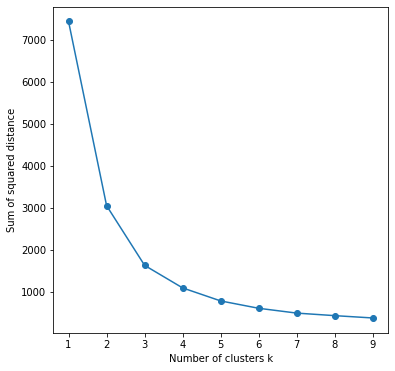

```python
#see the good clusters' number
sse = []
list_k = list(range(1, 10))
for k in list_k:
    km = KMeans(n_clusters=k)
    km.fit(X)
    sse.append(km.inertia_)

plt.figure(figsize=(6, 6))
plt.plot(list_k, sse, '-o')
plt.xlabel('Number of clusters k')
plt.ylabel('Sum of squared distance')
plt.show()
```

#### Silhouette Analysis

É un metodo di valutazione che può essere usato per determinare il grado di separazione tra i clusters.

Per ogni campione viene:

- Calcolata la distanza media di tutti i punti nello stesso cluster (ai)
- Calcolata la distanza media di tutti i punti nel cluster più vicino (bi)
- Calcolato il coefficiente di silhouette definito in tale intervallo [-1,1]:

se il valore del coefficiente di silhouette è pari a 0, significa che il campione è vicino ai cluster vicini. Se risulta pari a 1, il campione è lontano dai cluster vicini, infine se risulta essere pari a -1, il campione è assegnato al cluster sbagliato.

I coefficienti ottenuti devono essere più vicini a 1 per ottenere degli ottimi clusters.

Il risultato ottenuto consiglia di utilizzare un parametro k pari a 2.

[figure not shown]

[figure not shown]

[figure not shown]

```python
import numpy as np

def silhoutte(X, data_reduced):
      for i, k in enumerate([2, 3, 4]):
        fig, (ax1, ax2) = plt.subplots(1, 2)
        fig.set_size_inches(18, 7)

        # Run the Kmeans algorithm
        km = KMeans(n_clusters=k)
        labels = km.fit_predict(X)
        centroids = km.cluster_centers_

        # Get silhouette samples
        silhouette_vals = silhouette_samples(X, labels)

        # Silhouette plot
        y_ticks = []
        y_lower, y_upper = 0, 0
        for i, cluster in enumerate(np.unique(labels)):
            cluster_silhouette_vals = silhouette_vals[labels == cluster]
            cluster_silhouette_vals.sort()
            y_upper += len(cluster_silhouette_vals)
            ax1.barh(range(y_lower, y_upper), cluster_silhouette_vals, edgecolor='none', height=1)
            ax1.text(-0.03, (y_lower + y_upper) / 2, str(i + 1))
            y_lower += len(cluster_silhouette_vals)

        # Get the average silhouette score and plot it
        avg_score = np.mean(silhouette_vals)
        ax1.axvline(avg_score, linestyle='--', linewidth=2, color='green')
        ax1.set_yticks([])
        ax1.set_xlim([-0.1, 1])
        ax1.set_xlabel('Silhouette coefficient values')
        ax1.set_ylabel('Cluster labels')
        ax1.set_title('Silhouette plot for the various clusters', y=1.02)

        # Scatter plot of data colored with labels
        ax2.scatter(data_reduced[0], data_reduced[1], c=labels)
        ax2.scatter(centroids[:, 0], centroids[:, 1], marker='*', c='r', s=250)
        ax2.set_xlim([-6, 6])
        ax2.set_ylim([-2, 2])
        ax2.set_xlabel('Eruption time in mins')
        ax2.set_ylabel('Waiting time to next eruption')
        ax2.set_title('Visualization of clustered data', y=1.02)
        ax2.set_aspect('equal')
        plt.tight_layout()
        plt.suptitle(f'Silhouette analysis using k = {k}',
                    fontsize=16, fontweight='semibold', y=1.05)

        plt.show()

#second type to Evaluation Method
silhoutte(X, data_reduced)
```

**Ad ogni combinazione di features** viene mostrato un grafico con asse x pari alla caratteristica x' e con asse y pari alla caratteristica y'.

Mostriamo un **eventuale** ulteriore grafico in cui secondo un determinato intervallo scelto da noi visualizziamo le canzoni che risultano avere valori più vicini alla nostra canzone. Se non sono presenti canzoni nel nostro intervallo, l'ulteriore grafico non viene mostrato.

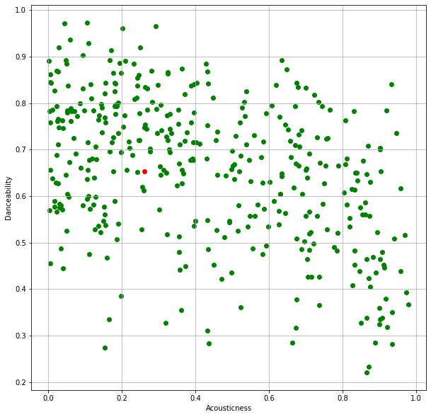

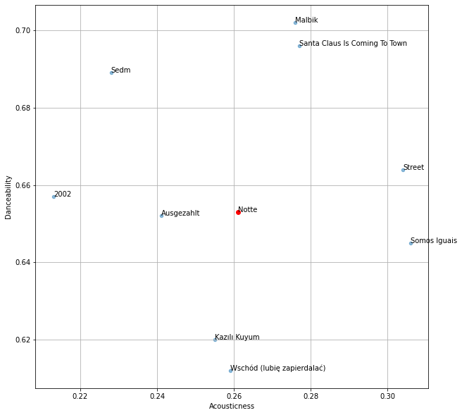

```
Total Stream: 53883.0
MPI: 30.77777777777778
MPA: 0.4977777777777778
PresenceIN:  1
```

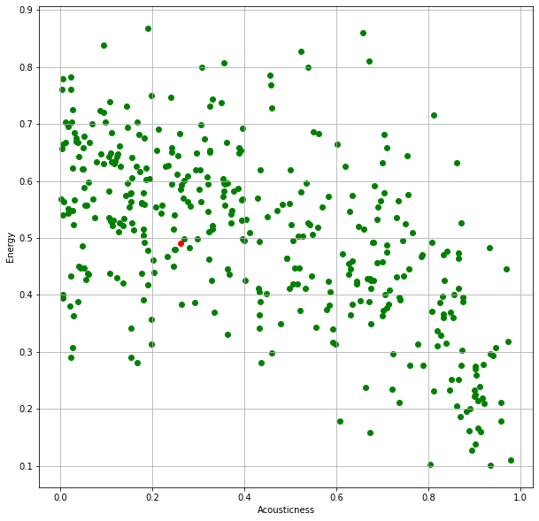

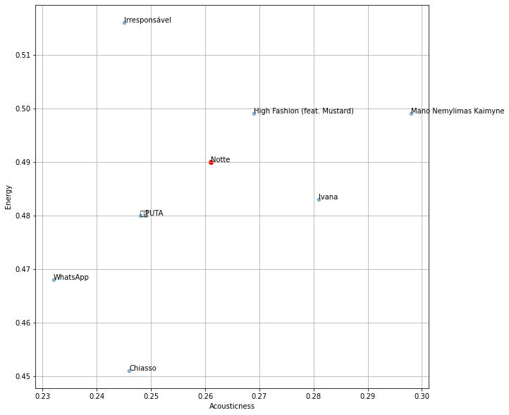

```
Total Stream: 185920.75
MPI: 30.625
MPA: 0.49375
PresenceIN:  2
```

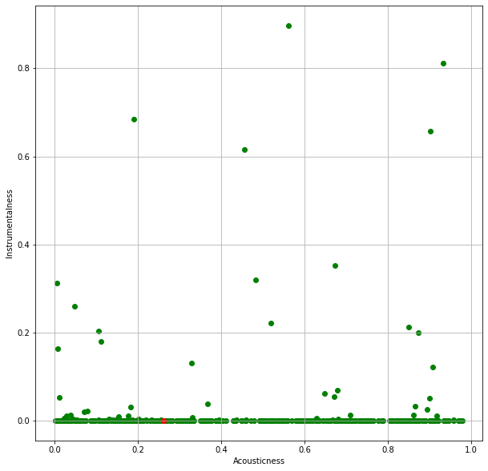

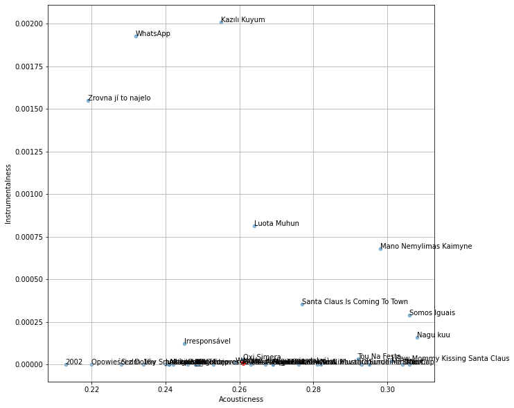

```
Total Stream: 67288.97297297297
MPI: 31.405405405405407
MPA: 0.5067567567567568
PresenceIN:  2
```

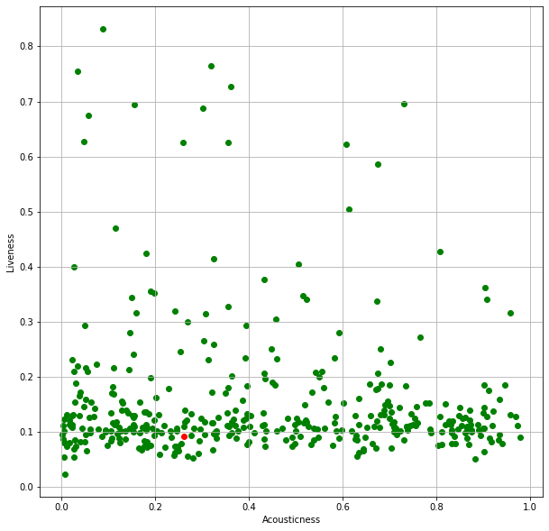

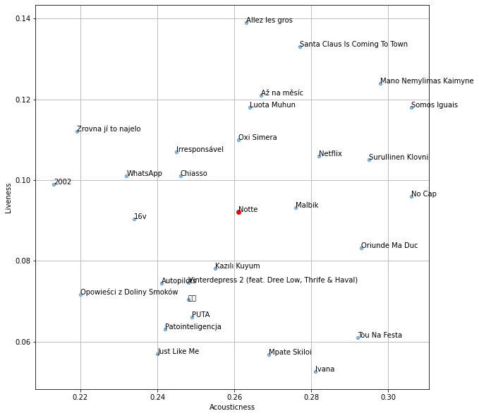

```
Total Stream: 41580.10344827586
MPI: 29.689655172413794
MPA: 0.47862068965517246
PresenceIN:  2
```

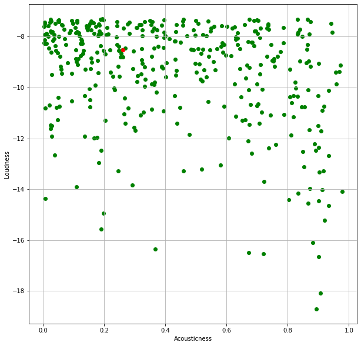

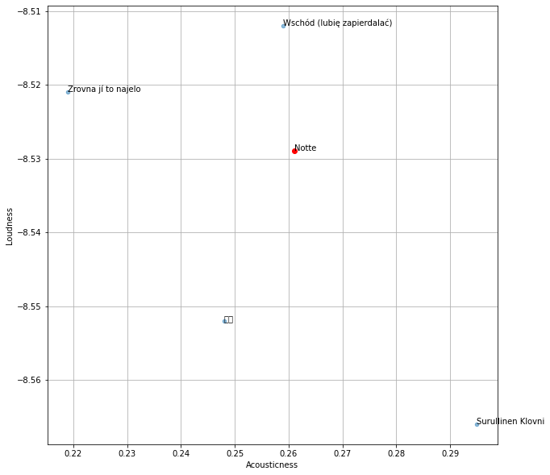

```
Total Stream: 22744.0
MPI: 27.0
MPA: 0.4375
PresenceIN:  1
```

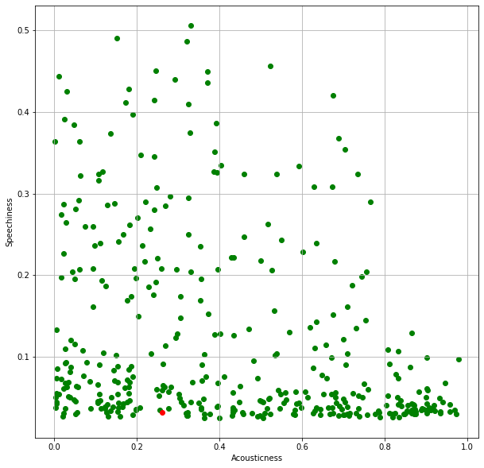

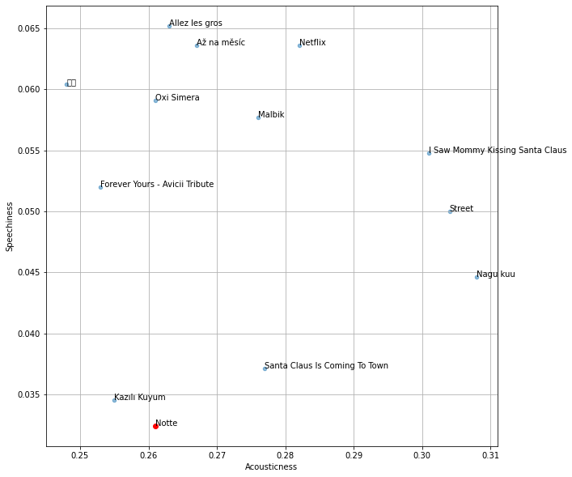

```
Total Stream: 38952.0
MPI: 29.25
MPA: 0.4725
PresenceIN:  2
```

[59 more figures not shown]

```
Total Stream: 16302.0
MPI: 2.0
MPA: 0.02999999999999997
PresenceIN:  1
```

```python
from itertools import combinations
import math

def common_member(a, b):
    a_set = set(a)
    b_set = set(b)
    if (a_set & b_set):
        return list(a_set & b_set)
    else:
        return 0

def result_stats_new_song(combine_info, normalized_dataset, temp, dataset):
    list_of_none_features = []
    old_len = len(normalized_dataset) - 1
    normalized_dataset = normalized_dataset[normalized_dataset.Labels == normalized_dataset.loc[len(normalized_dataset)-1].Labels]
    normalized_dataset = normalized_dataset.drop(old_len)

    for x in combine_info:
        X = x[0]
        Y = x[1]

        #Plot the first values and add the new value, we want to analyze 10 songs
        plt.scatter( normalized_dataset[[X]], normalized_dataset[[Y]], color ="green"  )
        plt.scatter( temp[X], temp[Y], color ="red"  )
        plt.xlabel(X)
        plt.ylabel(Y)
        plt.grid()

        plt.show()

        #zoom to the cluster
        for i in range(normalized_dataset.shape[1]):
            group_x = normalized_dataset.loc[ (normalized_dataset[X] < ( temp[X] + 0.05 )) & (normalized_dataset[X] > ( temp[X] - 0.05 )) , X]
            group_y = normalized_dataset.loc[ (normalized_dataset[Y] < ( temp[Y] + 0.05 )) & (normalized_dataset[Y] > ( temp[Y] - 0.05 )) , Y]

        around_values = common_member(list(group_x.index), list(group_y.index))

        if around_values:
            row_data = normalized_dataset.loc[around_values, :].copy()
            row_data[['Total Stream','MediumPositionsINTERN','MediumPositionsALL','PresenceIN']] = (row_data[['Total Stream','MediumPositionsINTERN','MediumPositionsALL','PresenceIN']]*dataset[['Total Stream','MediumPositionsINTERN','MediumPositionsALL','PresenceIN']].std() ) + dataset[['Total Stream','MediumPositionsINTERN','MediumPositionsALL','PresenceIN']].mean()

            ax = row_data.plot.scatter(x=list(row_data[[X]]), y=list(row_data[[Y]]), alpha=0.5)
            for i, txt in enumerate(row_data.Song):
                ax.annotate(txt, (row_data[X].iat[i],row_data[Y].iat[i]))

            plt.scatter( temp[X], temp[Y], color ="red"  )
            plt.annotate(search_song, (temp[X], temp[Y]) )
            plt.xlabel(X)
            plt.ylabel(Y)
            plt.grid()

            plt.show()

            total_stream_newartist = row_data[['Total Stream']].sum() / len(around_values)
            print(f"Total Stream: {total_stream_newartist[0]}")

            MPI_newartist = row_data[['MediumPositionsINTERN']].sum() / len(around_values)
            print(f"MPI: {MPI_newartist[0]}")

            MPA_newartist = row_data[['MediumPositionsALL']].sum() / len(around_values)
            print(f"MPA: {MPA_newartist[0]}")

            PresenceIN_newartist = math.ceil(row_data[['PresenceIN']].sum() / len(around_values))
            print("PresenceIN: ", PresenceIN_newartist)

            list_of_none_features.append([total_stream_newartist,MPI_newartist,MPA_newartist,PresenceIN_newartist])
        else:
            row_data[['Total Stream','MediumPositionsINTERN','MediumPositionsALL','PresenceIN']] = ( normalized_dataset[['Total Stream','MediumPositionsINTERN','MediumPositionsALL','PresenceIN']]*dataset[['Total Stream','MediumPositionsINTERN','MediumPositionsALL','PresenceIN']].std() ) + dataset[['Total Stream','MediumPositionsINTERN','MediumPositionsALL','PresenceIN']].mean()

            total_stream_newartist = row_data[['Total Stream']].mean()
            print(f"Total Stream: {total_stream_newartist[0]}")

            MPI_newartist = row_data[['MediumPositionsINTERN']].mean()
            print(f"MPI: {MPI_newartist[0]}")

            MPA_newartist = row_data[['MediumPositionsALL']].mean()
            print(f"MPA: {MPA_newartist[0]}")

            PresenceIN_newartist = math.ceil(row_data[['PresenceIN']].mean())
            print("PresenceIN: ", PresenceIN_newartist)

            list_of_none_features.append([total_stream_newartist,MPI_newartist,MPA_newartist,PresenceIN_newartist])

    return list_of_none_features

#let's start to analyze new song
list_for_analysis = ['Acousticness', 'Danceability', 'Energy', 'Instrumentalness', 'Liveness', 'Loudness', 'Speechiness', 'Valence','Tempo']
combine_info = list(combinations(list_for_analysis, 2))

list_of_none_features = result_stats_new_song(combine_info, normalized_dataset, temp, dataset)
```

Per il calcolo dei quattro valori ipotetici per ciascuno step abbiamo applicato l'inverse z-score dei valori. L'inverse Z-score è la formula inversa che abbiamo applicato per normalizzare gli iniziali valori del nostro dataset.

In questo modo possiamo ottenere due casi:

- Se viene mostrato il grafico in cui ricadono nell'intervallo le canzoni più vicine alla nostra canzone, vengono considerati i valori di ciascuna canzone eccetto la nostra ed i risultati ottenuti vengono inseriti in una lista che viene poi normalizzata per ciascun valore.
- Se **non** viene mostrato il grafico in cui ricadono nell'intervallo le canzoni più vicine alla nostra canzone, vengono considerati i valori di **tutte** le canzoni etichettate allo stesso modo in cui è etichettata la nostra canzone, considerando una media dei valori ottenuti vengono inseriti in una lista.

Infine, otteniamo i valori e gestiamo la lista di liste appena creata per ottenere i quattro valori e fornire un risultato tale da classificare la canzone come un'ipotetica **hit o no**.

```python
total_stream_newartist = 0
MPI_newartist = 0
MPA_newartist = 0
PresenceIN_newartist = 0
for x in list_of_none_features:
    for i,single_feature in enumerate(x):
        if i == 0:
            total_stream_newartist += single_feature
        elif i == 1:
            MPI_newartist += single_feature
        elif i == 2:
            MPA_newartist += single_feature
        else:
            PresenceIN_newartist += single_feature

total_stream_newartist = math.ceil( abs(total_stream_newartist)/ 2 )
MPI_newartist = math.ceil(abs(MPI_newartist)/len(list_of_none_features))
MPA_newartist = float( round(abs(MPA_newartist)/len(list_of_none_features),2) )
PresenceIN_newartist = math.ceil(PresenceIN_newartist/len(list_of_none_features))
```

È dunque un'ipotetica hit o no?

```python
if total_stream_newartist > 1000 and total_stream_newartist < 500000:
    print("\nNOT AN HIT")
    print(f"Total Stream: {total_stream_newartist}, MPI: {MPI_newartist}, MPA: {MPA_newartist}, PresenceIN: {PresenceIN_newartist}")
elif total_stream_newartist > 500000 and total_stream_newartist < 2000000:
    print("\nLOCAL HIT")
    print(f"Total Stream: {total_stream_newartist}, MPI: {MPI_newartist}, MPA: {MPA_newartist}, PresenceIN: {PresenceIN_newartist}")
else:
    print("\nMAYBE GLOBAL HIT!")
    print(f"Total Stream: {total_stream_newartist}, MPI: {MPI_newartist}, MPA: {MPA_newartist}, PresenceIN: {PresenceIN_newartist}")
```

```
LOCAL HIT
Total Stream: 1383226, MPI: 26, MPA: 0.41, PresenceIN: 2
```

# Considerazioni e Conclusioni

I risultati ottenuti sono stati in alcuni casi molto veritieri. È vero che considerando solo la grandezza del dataset di Spotify non abbiamo emulato il progetto di Snafu per intero. Infatti, Snafu giorno per giorno utilizza molteplici datasets di tutte le piattaforme musicali disponibili nel mondo e sicuramente maggiormente considerate.

Nonostante la restrizione di poter effettuare questi calcoli sfruttando solamente l'API di Spotify e considerando solamente un giorno per cercare di emulare ciò che fa l'azienda giornalmente, i risultati ottenuti, applicando il metodo di clustering dei dati con il ridimensionamento PCA, hanno fatto emergere un gruppo di canzoni simili nella loro sonorità.

È vero anche che il suono riprodotto nelle tre canzoni mostrate precedentemente possono essere considerate come canzoni di sonorità totalmente differente, ma è anche vero che **l'opinione è soggettiva**.

Se l'azienda riuscisse a migliorare notevolmente l'algoritmo, ottendo dei risultati di valutazione sempre più alti dei precedenti stravolgerebbe il mercato musicale odierno. Proiettando le etichette discografiche all'utilizzo sempre più accanito di software di questo calibro.

# Bibliografia

1. Articolo scritto da Simone Cosimi di TheNextTech in cui parla di Snafu https://thenexttech.startupitalia.eu/snafu-ora-le-hit-musicali-le-sceglie-lintelligenza-artificiale
2. Articolo scritto da Imad Dabbura di Towards Data Science https://towardsdatascience.com/k-means-clustering-algorithm-applications-evaluation-methods-and-drawbacks-aa03e644b48a
3. Definizioni e chiarimenti su alcuni termini prese sull'enciclopedia online https://www.wikipedia.org/
4. Documentazione API Spotify per la ricerca di alcune funzioni utili per il progetto https://developer.spotify.com/documentation/